# New report

O. Denas

June 5, 2017

# 1 Current performance – not working

# 2 Input properties

All experiments are performed on the following inputs (the mutation period refers to the index sequence):

Input datasets

| s_type | t_type | slen | tlen | alp |
| --- | --- | --- | --- | --- |
| rep | dis | 100’000’000 | 500’000 | abcdefghijklmnopqrst |
| rep | dis | 100’000’000 | 500’000 | abcd |
| rep | sim | 100’000’000 | 500’000 | abcdefghijklmnopqrst |
| rep | sim | 100’000’000 | 500’000 | abcd |
| rnd | dis | 100’000’000 | 500’000 | abcdefghijklmnopqrst |
| rnd | dis | 100’000’000 | 500’000 | abcd |
| rnd | sim | 100’000’000 | 500’000 | abcdefghijklmnopqrst |
| rnd | sim | 100’000’000 | 500’000 | abcd |

In this section, we run the matching statistics algorithm and gather information on the way.

## 2.1 Node properties

Before making a `wl(v, c)` call register whether `v` is a maximal repeat, and whether the Weiner link exists or not.

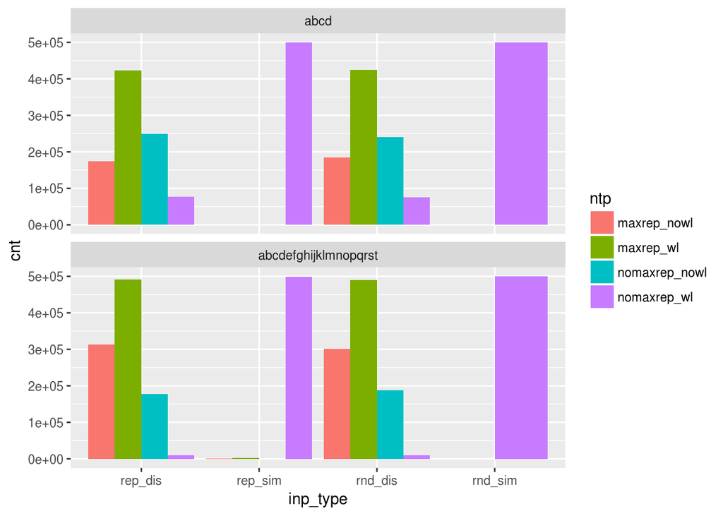

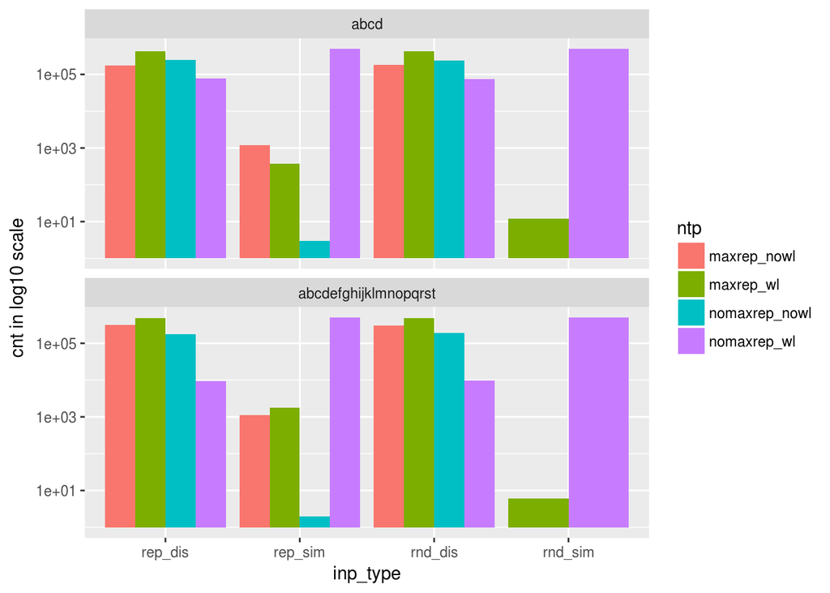

## 2.2 Consecutive wl() calls

During the MS vector construction, count the number of consecutive wl() calls due to matches between reversed indexed string and the query. In other words count the $k$-length iterations of the while cycle.

```
## # A tibble: 9 x 4
##   inp_type                  alp    key value
##      <chr>                <chr>  <dbl> <int>
## 1  rep_sim                 abcd     47     1
## 2  rep_sim                 abcd   1432     1
## 3  rep_sim                 abcd  62960     1
## 4  rep_sim                 abcd 435557     1
## 5  rep_sim abcdefghijklmnopqrst     47     1
## 6  rep_sim abcdefghijklmnopqrst  64393     1
## 7  rep_sim abcdefghijklmnopqrst 435557     1
## 8  rnd_sim abcdefghijklmnopqrst 499999     1
## 9  rnd_sim                 abcd 499999     1
```

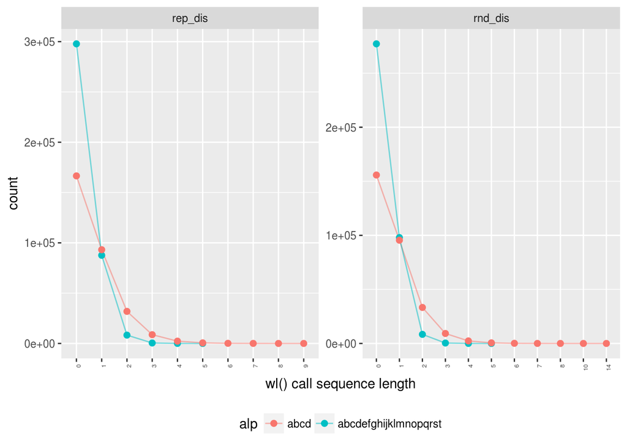

## 2.3 Consecutive parent() calls

During the MS vector construction, count the number of consecutive `parent()` calls after a failed `wl()` call.

```
## # A tibble: 8 x 4
##   inp_type                  alp   key value
##      <chr>                <chr> <dbl> <int>
## 1  rep_sim                 abcd     1     2
## 2  rep_sim                 abcd    21     1
## 3  rep_sim                 abcd     1     2
## 4  rep_sim                 abcd  1176     1
## 5  rep_sim abcdefghijklmnopqrst     1     1
## 6  rep_sim abcdefghijklmnopqrst  1426     1
## 7  rep_sim abcdefghijklmnopqrst     1     1
## 8  rep_sim abcdefghijklmnopqrst  1103     1
```

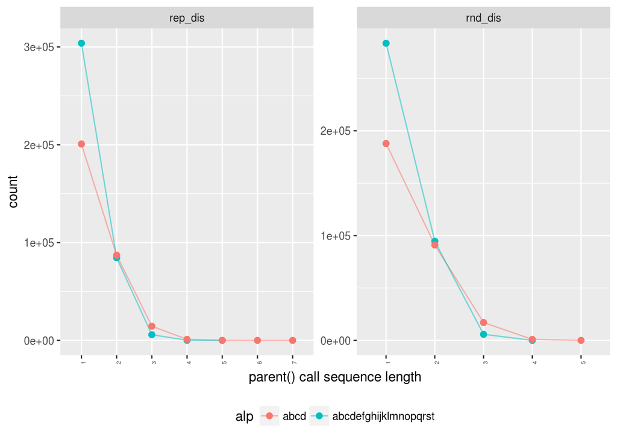

# 3 wl() optimizations

## 3.1 sandbox tests

The 4 plots correspond to combinations of index size (one 100Mb and one 1Mb) and alphabet size (one 4 and one 20). Each plot shows 6 measurements based on

- node type: leaf (l) or internal (i)
- maximality: maximal (m) or non-maximal (nm)
- WL presence: present (wlp) or absent (wla)

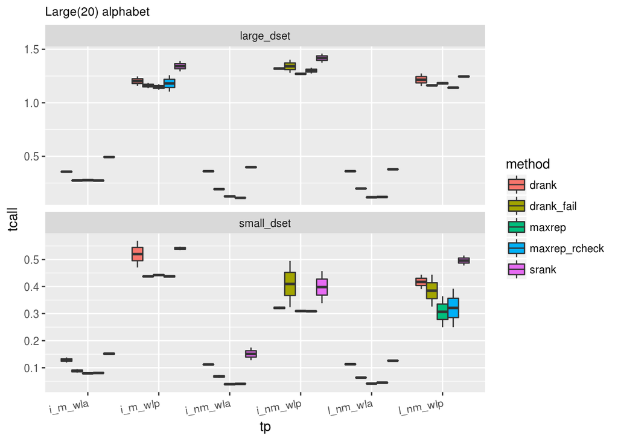

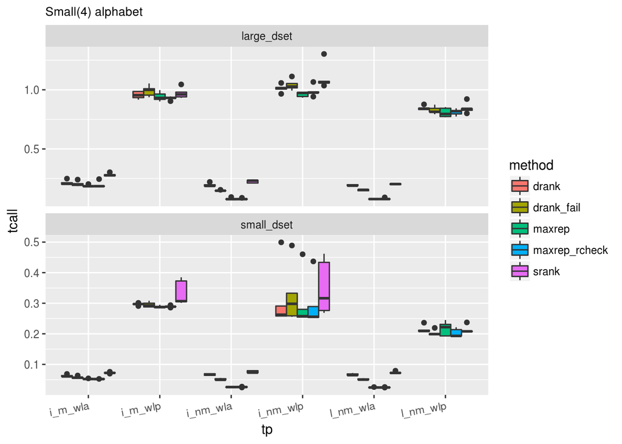

[figure not shown]

## 3.2 full tests

The boxplots report the raw times for the MS construction.

### 3.2.1 drank

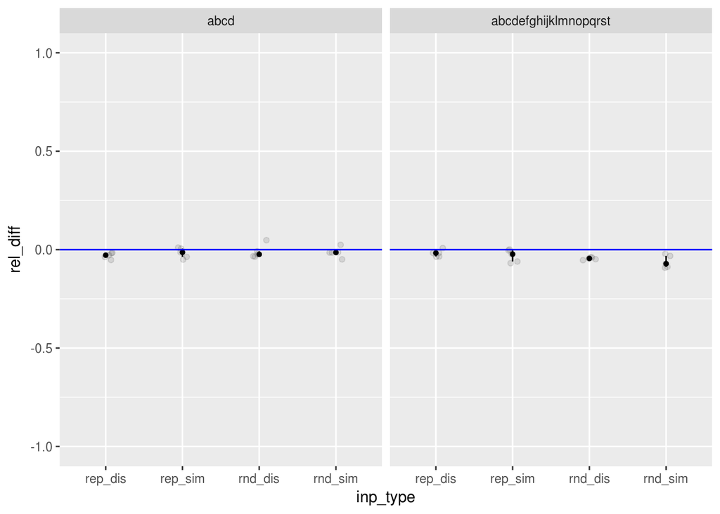

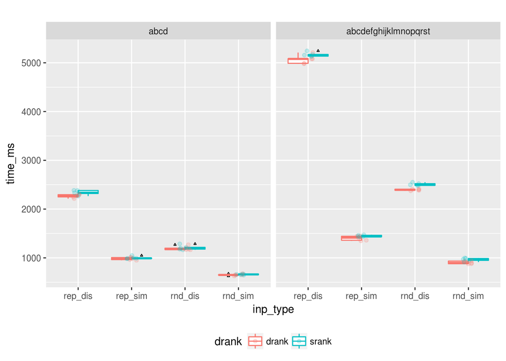

### 3.2.2 Lazy

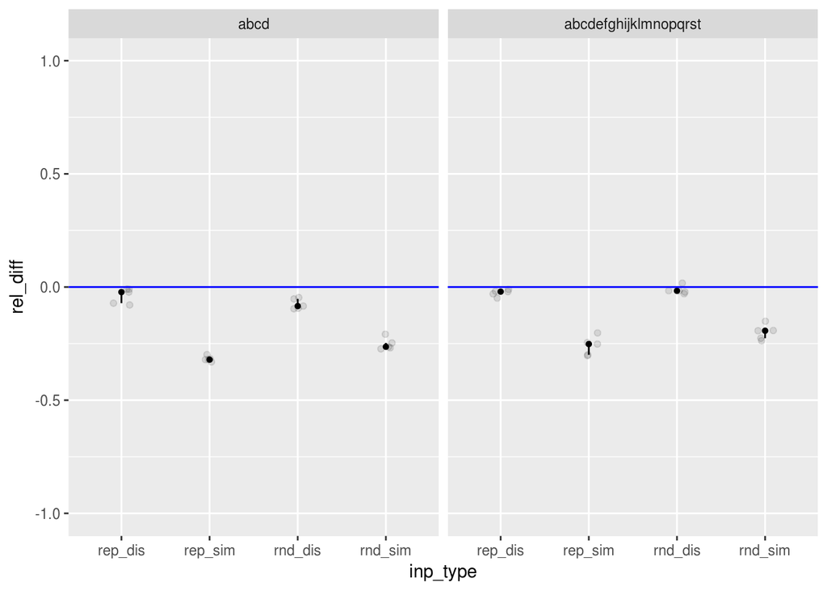

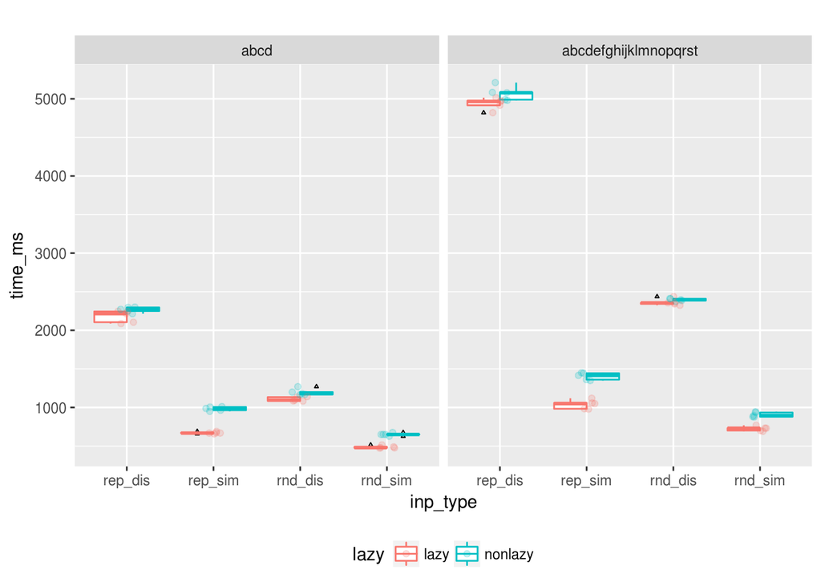

### 3.2.3 Fail

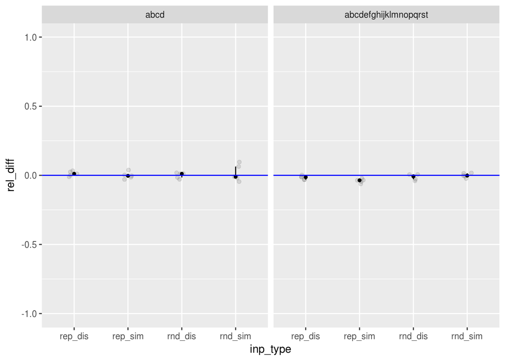

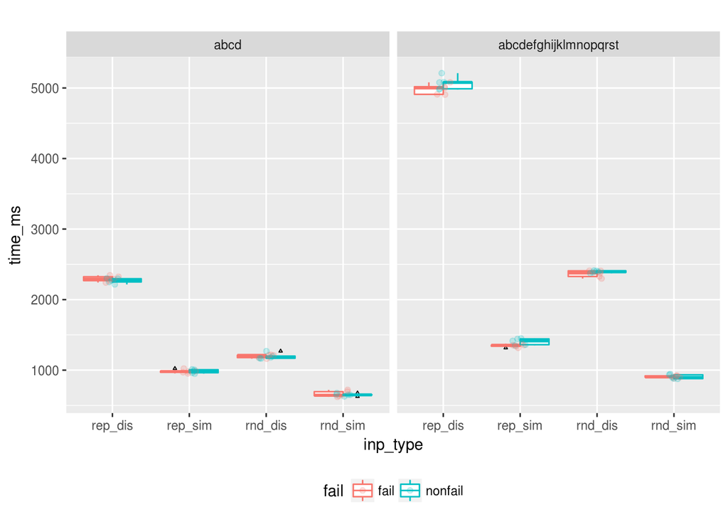

### 3.2.4 all flags (lazy, fail, double_rank) vs. single rank

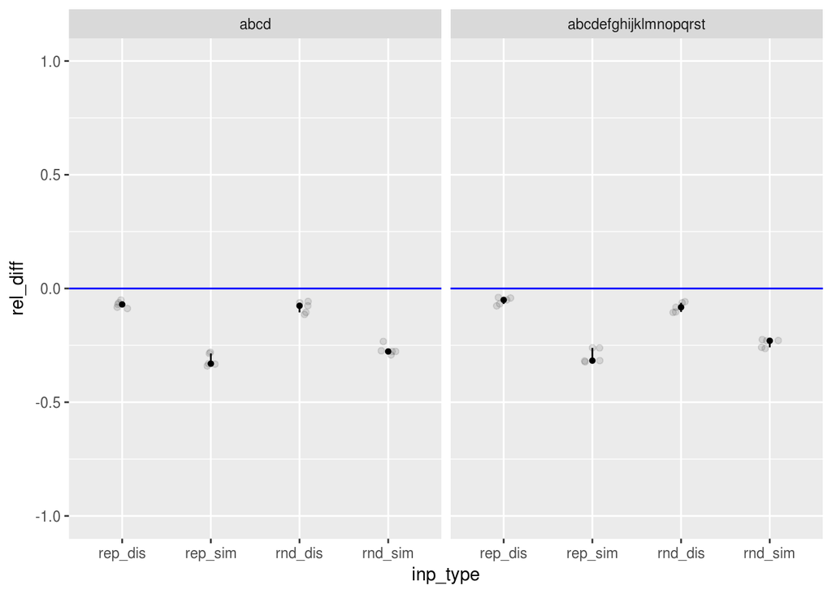

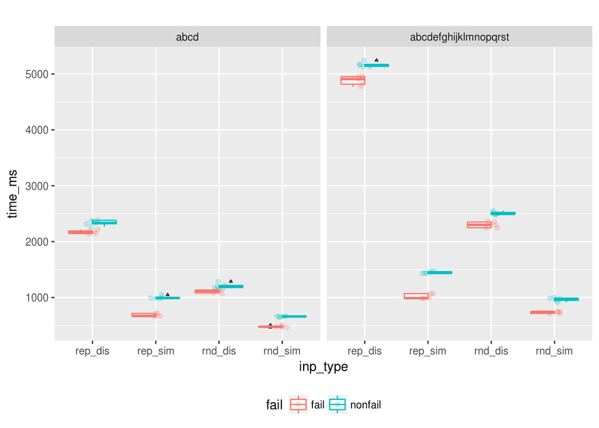

### 3.2.5 maxrep

#### 3.2.5.1 maxrep_vanilla vs. non-maxrep

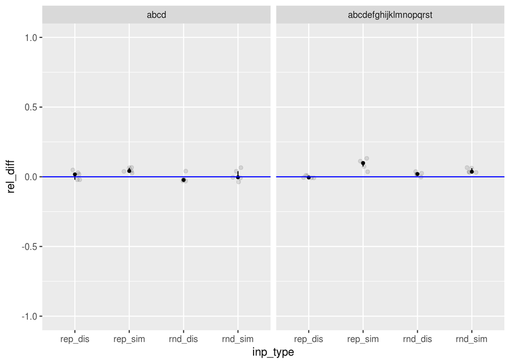

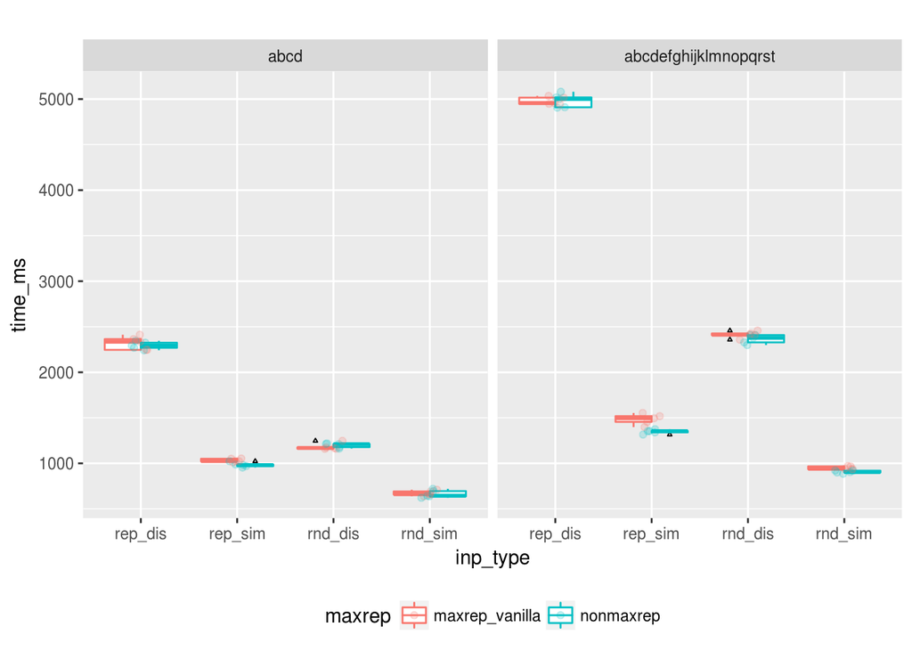

#### 3.2.5.2 maxrep+rank_and_check vs. non-maxrep

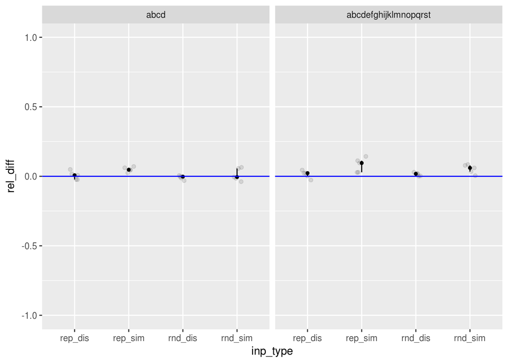

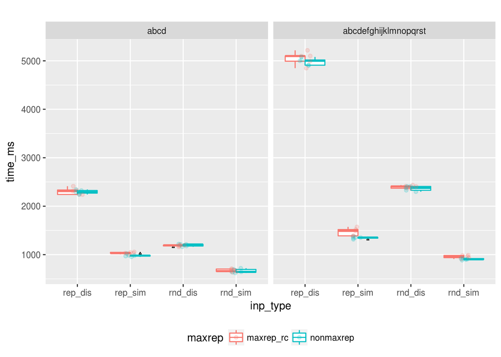

#### 3.2.5.3 maxrep+rank_and_check vs. maxrep_vanilla

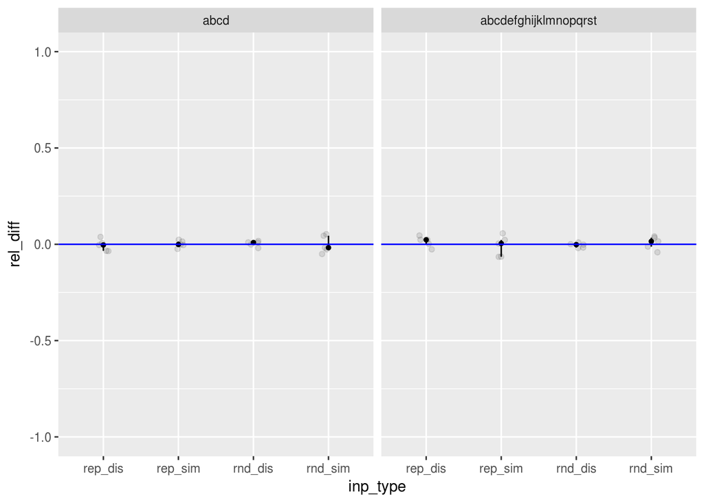

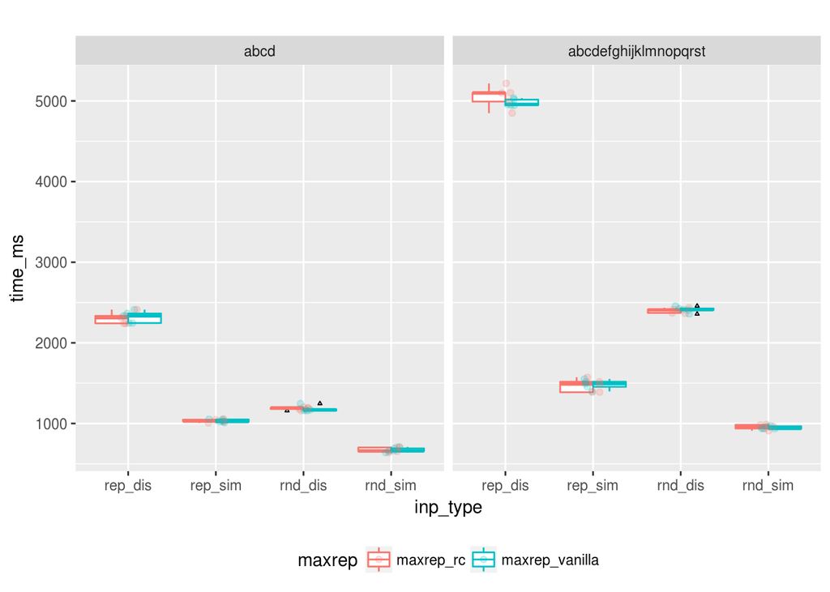

# 4 parent optimizations

## 4.1 sandbox tests

### 4.1.1 select at dist

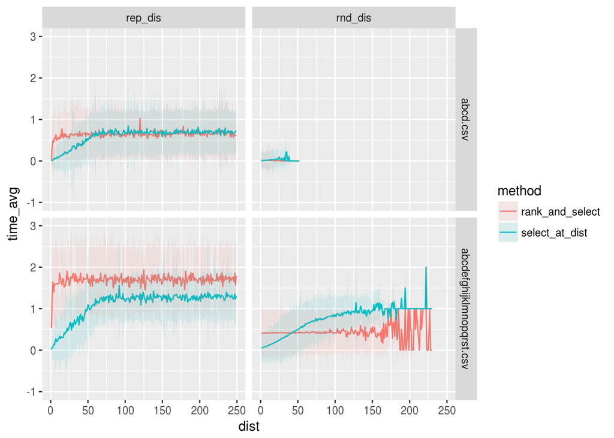

### 4.1.2 lowest maximal ancestor

Generate all tuples `(v, c, d)` from a tree where, `n` is an internal node, `c` a character, and `d = depth(v) - depth(u)` with `u` the lowest maximal ancestor.

Then shuffle and time the two ways of finding `u`: using the maxrep or with a sequence of parent calls.

When the nr of calls is small the time resolution is not big enough and the numbers are not to be trusted.

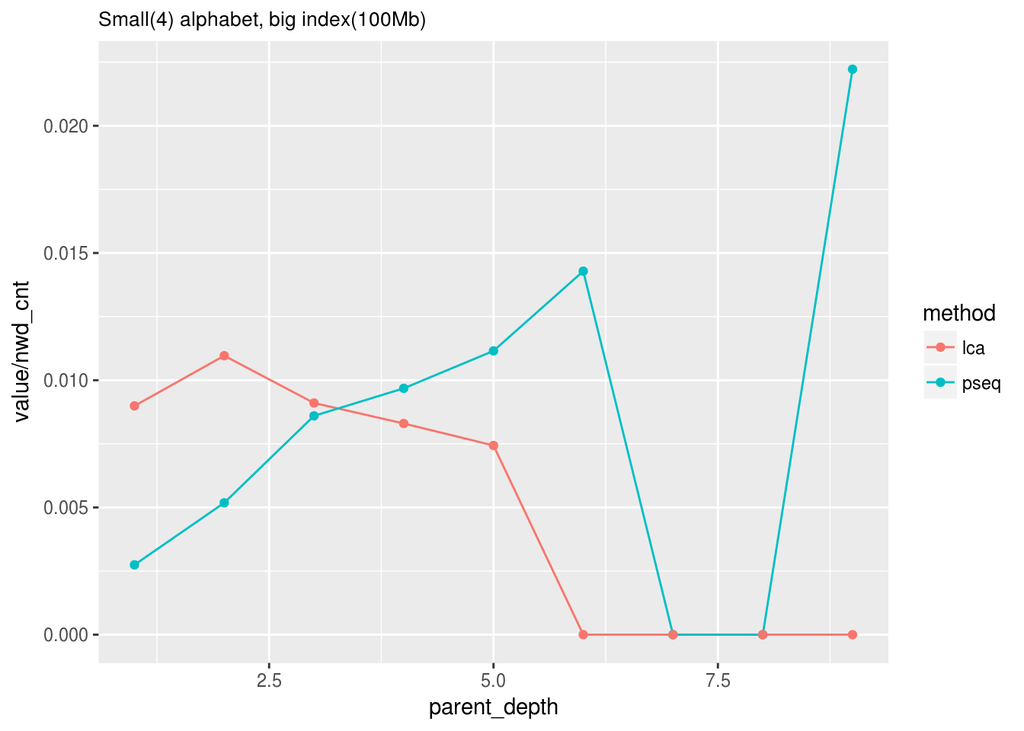

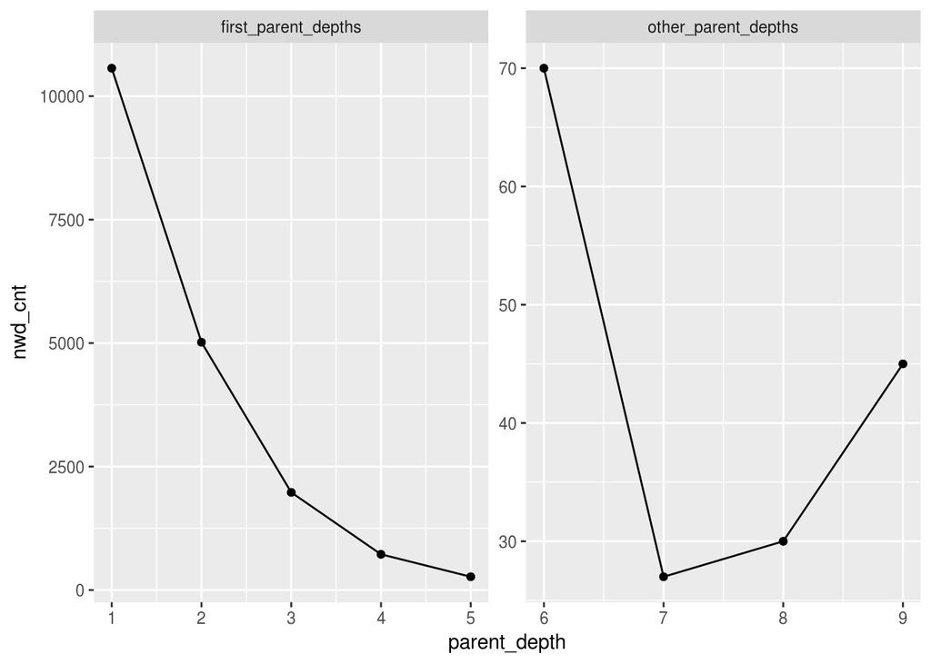

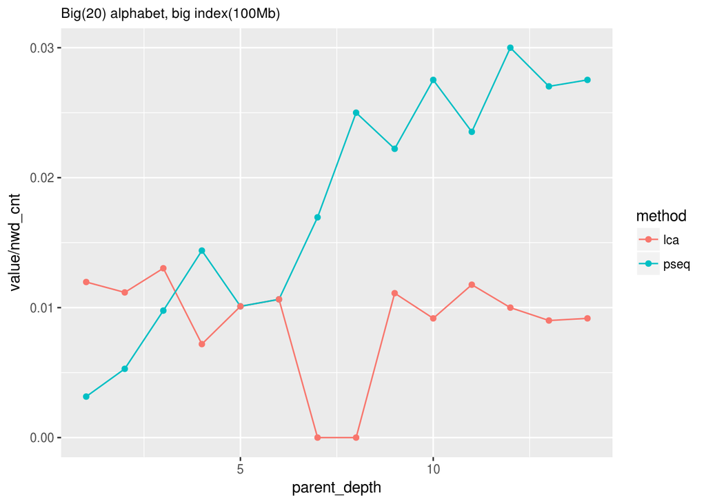

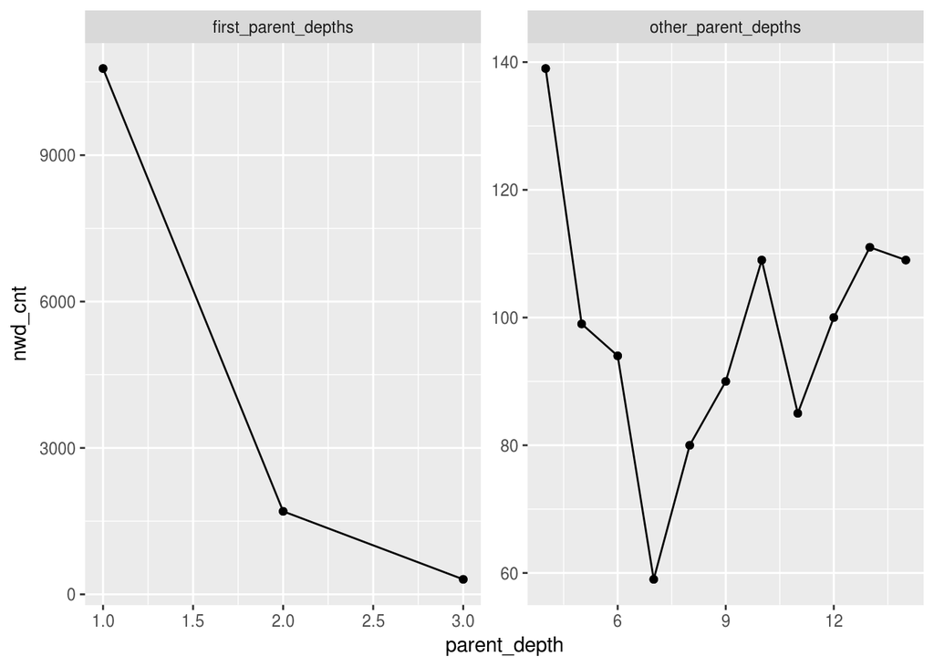

By counting the number of consecutive parent calls (for each number of consecutive calls) we project the runtime of each method for an input type as below.

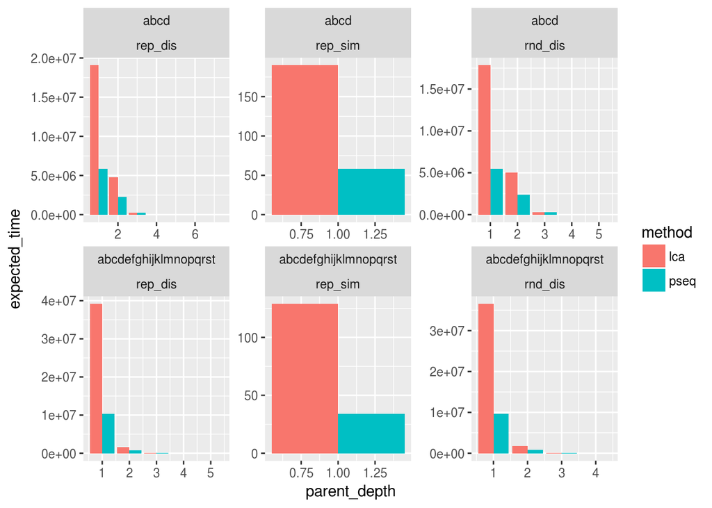

## 4.2 full tests

** FLAGS ARE INVERTED, WHAT YOU SEE IS A SLOWDOWN **

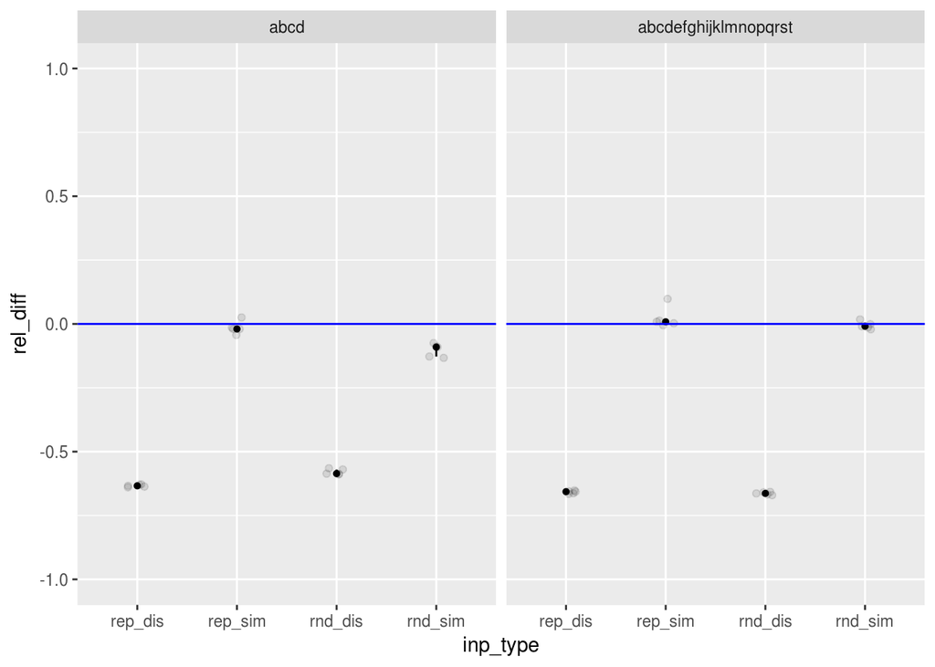

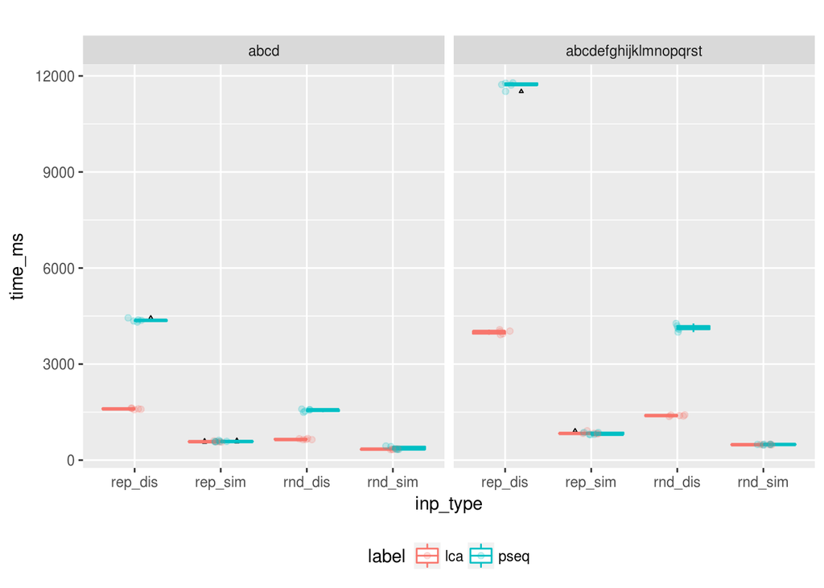

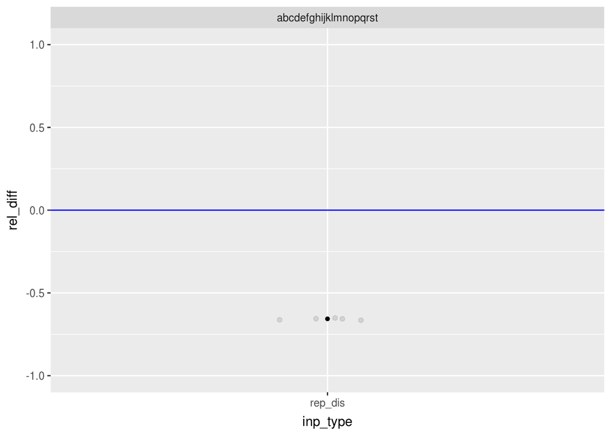

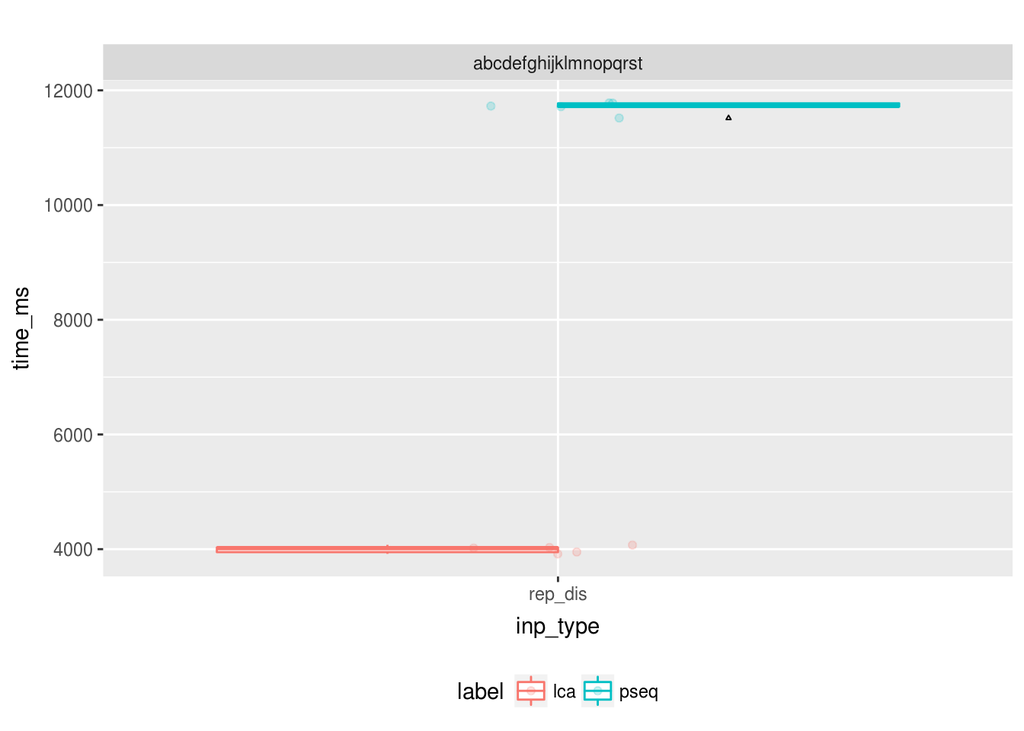

# 5 parallelization

> TODO: there is currently a bug on the parallel version of the program for particular inputs. At the moment fixing it is not a priority.